# Reproducible Research: Peer Assessment 1

The original dataset for this assignment (i.e. “activity.zip”" file) must be in the folder “RepData_PeerAssessment1”.

The following libraries will be used during the process:

```r
library(dplyr) # For data manipulation
library(ggplot2) # For data visualization
library(gridExtra) # For data visualization
library(timeDate) # For manipulating dates
```

## 1.- Loading and preprocessing the data

Considering the original dataset, we should assign the following classes to each variable:

- **steps**: Numerical class.
- **date**: Date class.
- **inteval**: Numerical class.

So, let’s create a vector with the classes for each variable

```r
data_types <- c("numeric", "Date", "numeric")
```

Now, we are going to unzip the dataset and load it as a raw dataset in our working space:

```r
data_file <- unzip("activity.zip")
raw_data <- read.csv(data_file, colClasses = data_types)
```

Let’s begin by doing some exploratory analysis. We can easily see that there are 17568 observations in the dataset. But, is the dataset complete? Let’s see a summary of the variables:

```
##      steps             date               interval
##  Min.   :  0.00   Min.   :2012-10-01   Min.   :   0.0
##  1st Qu.:  0.00   1st Qu.:2012-10-16   1st Qu.: 588.8
##  Median :  0.00   Median :2012-10-31   Median :1177.5
##  Mean   : 37.38   Mean   :2012-10-31   Mean   :1177.5
##  3rd Qu.: 12.00   3rd Qu.:2012-11-15   3rd Qu.:1766.2
##  Max.   :806.00   Max.   :2012-11-30   Max.   :2355.0
##  NA's   :2304
```

From this summary, we can derive that 2304 observations have a NA in the “steps” variable. Hence, we need to transform the raw dataset into a clean dataset with 15264 observations. Let’s create this clean dataset.

```r
data <- raw_data[!is.na(raw_data$steps),]
```

Now the clean dataset has 15264 observations as we mentioned before.

## 2.- What is mean total number of steps taken per day?

We need to regroup the dataset in order to easily report the total number of steps taken per day. Let’s create a new variable that will ease this process:

```r
total_steps <- summarise(group_by(data, date), total = sum(steps))
```

Let’s plot this variable:

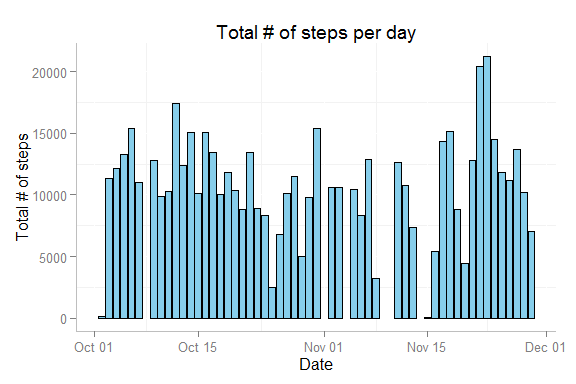

From this summarised data we can obtain the mean (in red) and the median (in green) and plot it over the previous graph. Since the values are so close the lines overlap.

```r
mean(total_steps$total)
```

```
## [1] 10766.19
```

```r
median(total_steps$total)
```

```
## [1] 10765
```

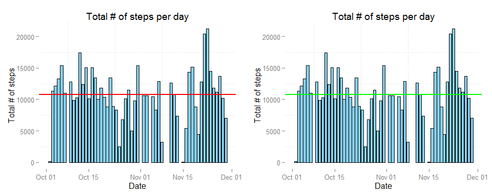

## 3.- What is the average daily activity pattern?

Similarly as we did for section 2, we need to regroup the dataset in order to report the average number of steps taken per interval. Let’s create a new variable:

```r
interval_steps <- summarise(group_by(data, interval), average = mean(steps))
```

Let’s plot this variable:

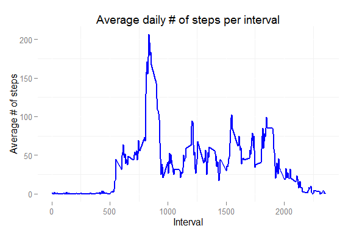

The interval with the highest value would be the interval 835 according to the following function:

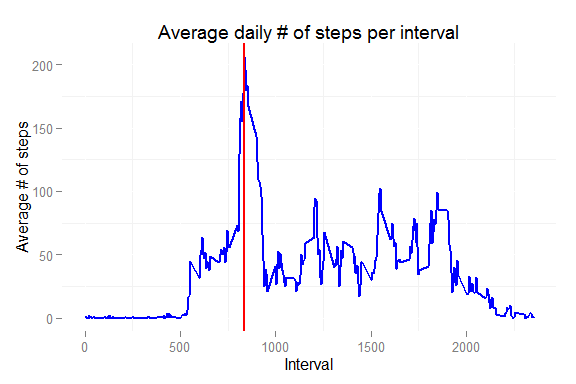

```r
interval_steps[which(interval_steps$average == max(interval_steps$average)),1]
```

[output not shown]

## 4.- Imputing missing values

From the analysis made for the first section, we saw that 2304 observations in the raw data have a NA in the “steps” variable which is the only variable with NA ocurrences. As per the exercise explains, we have to decide on a strategy to overcome this so we don’t end up with a biased dataset.

In my case, I have decided to use the strategy of filling the gaps by using the average # of steps for an interval. Therefore, I’m going to create a different data set where I’m going to assign the average # of steps for an interval to those observations with a NA in the steps variable. This is pretty easy to make using the data that we generated in the previous section.

```r
fill_data <- raw_data

for (i in 1:nrow(fill_data) ) {
        if(is.na(fill_data$steps[i])){
                fill_data$steps[i] = as.numeric(interval_steps[
                        which(interval_steps$interval == fill_data$interval[i]),2])
        }
}
```

We must group the dataset in order to report the total number of steps taken per day. Let’s create a new variable:

```r
total_steps_f <- summarise(group_by(fill_data, date), total = sum(steps))
```

Let’s plot this variable:

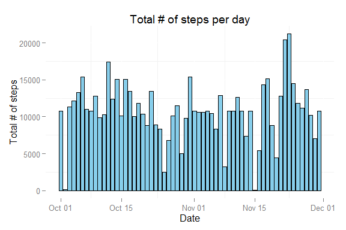

From this summarised data we can obtain the mean (in red) and the median (in green) and plot it over the previous graph like we did in section 2.

```r
mean(total_steps_f$total)
```

```
## [1] 10766.19
```

```r
median(total_steps_f$total)
```

```
## [1] 10766.19
```

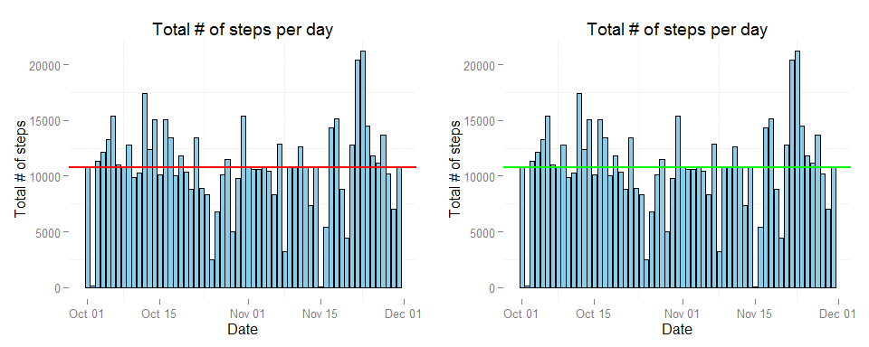

## 5.- Are there differences in activity patterns between weekdays and weekends?

```r
fill_data$weekday <- factor(isWeekday(fill_data$date), labels = c("Weekday","Weekend"))
```

In order to report the average # of steps per interval and divided by weekday or weekend, we need to create a new variable that summarises the necessary data.

```r
interval_steps_w <- summarise(group_by(fill_data, interval, weekday), average = mean(steps))
```

Let’s plot this variable:

[figure not shown]